# Multiple linear regression

## Grading the professor

Many college courses conclude by giving students the opportunity to evaluate the course and the instructor anonymously. However, the use of these student evaluations as an indicator of course quality and teaching effectiveness is often criticized because these measures may reflect the influence of non-teaching related characteristics, such as the physical appearance of the instructor. The article titled, “Beauty in the classroom: instructors’ pulchritude and putative pedagogical productivity” by Hamermesh and Parker found that instructors who are viewed to be better looking receive higher instructional ratings.

Here, you will analyze the data from this study in order to learn what goes into a positive professor evaluation.

## Getting Started

### The data

The data were gathered from end of semester student evaluations for a large sample of professors from the University of Texas at Austin. In addition, six students rated the professors’ physical appearance. The result is a data frame where each row contains a different course and columns represent variables about the courses and professors. This data frame can be found in the `OpenIntro` **Dataset Repository** as the dataset *evals*.

We have observations on 21 different variables, some categorical and some numerical. The meaning of each variable can be found by bringing up the codebook (click ) before importing the dataset from the Repository.

## Exploring the data

1. Is this an observational study or an experiment? The original research question posed in the paper is whether beauty leads directly to the differences in course evaluations. Given the study design, is it possible to answer this question as it is phrased? If not, rephrase the question.
2. Describe the distribution of *score*. Is the distribution skewed? What does that tell you about how students rate courses? Is this what you expected to see? Why, or why not?
3. Excluding *score*, select two other variables and describe their relationship with each other using an appropriate visualization.

## Simple linear regression

The fundamental phenomenon suggested by the study is that better looking teachers are evaluated more favorably. Let’s create a scatterplot to see if this appears to be the case:

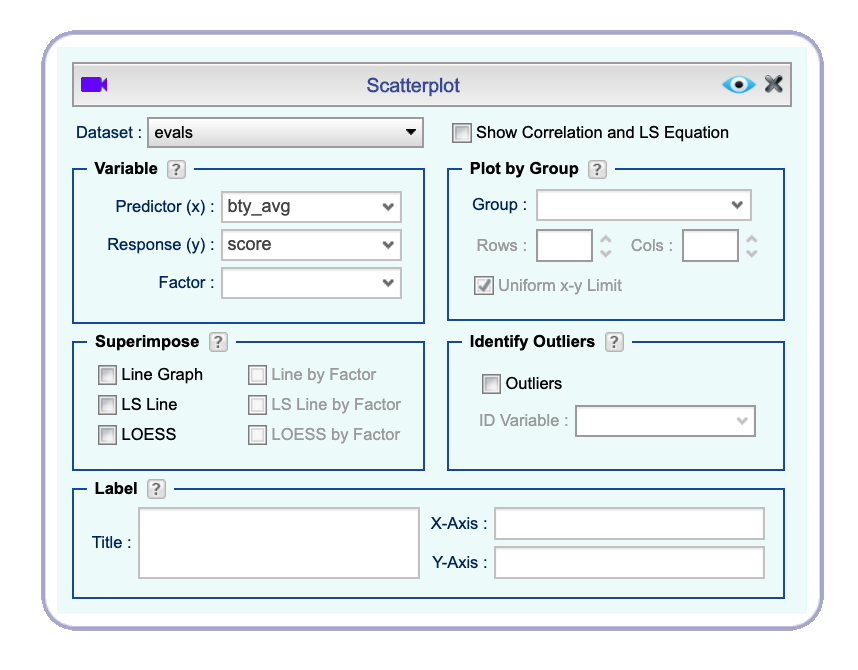

*Scatterplot dialog for plotting score vs. bty_avg*

Before you draw conclusions about the trend, compare the number of observations in the data frame with the approximate number of points on the scatterplot. Is anything awry?

Most likely, you noticed fewer points on the plot than the number of data values. It’s because many points overlap. To be able to see more points, we use a technique called *jittering*. Jittering is the act of adding random noise to data in order to prevent overlaps in graphs. To apply jittering to your plot, click the button and open the section `Attributes of Scatterplot Points, ...`. By default, the `Point-Line` tab opens. In the `Points` section, there are two text boxes labeled `X-Jitter` and `Y-Jitter`. Type positive values in these boxes to jitter the plot points in horizontal (x) or vertical (y) directions by a random amount. The larger the value, the more displaced the points get. Try a value of 3 for both the `X-Jitter` and the `Y-Jitter`. Click the `Preview` button to see how your plot changes.

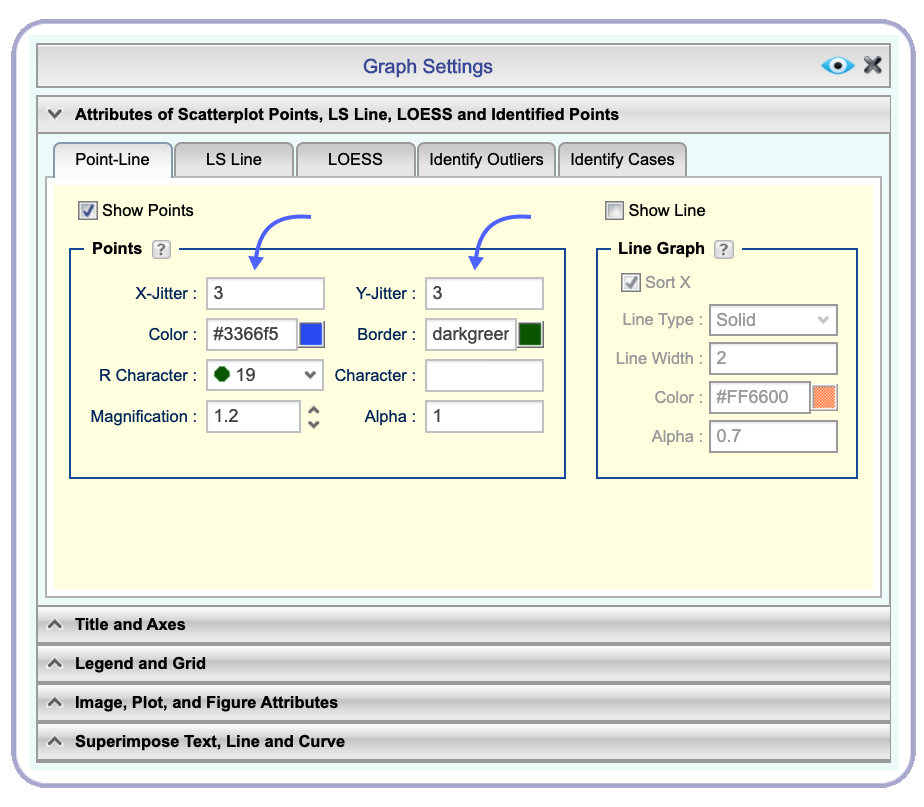

*Graph Settings dialog for jittering the points in the x and y directions*

1. Now that you have jittered the points, what was misleading about the initial scatterplot where you had not jittered the points?

Click and add the line of the best fit to your plot by checking the `LS Line` box in the **Scatterplot** dialog:

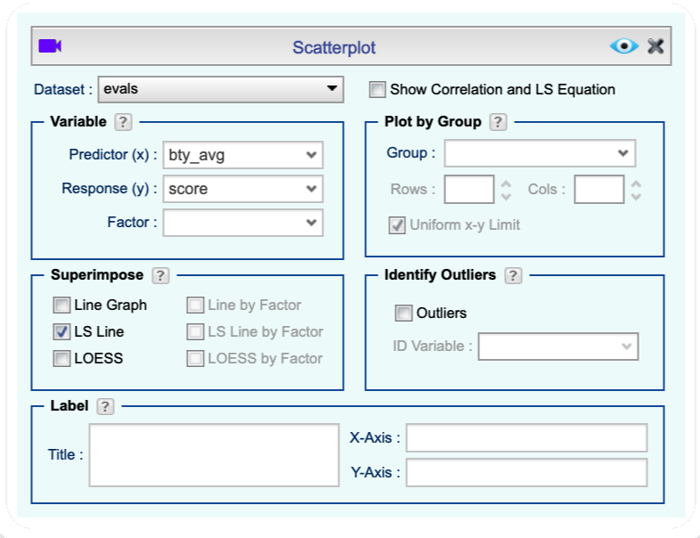

*Adding least squares line to the scatterplot*

1. Let’s see if the apparent trend in the plot is something more than natural variation. Use Rguroo’s **Linear Regression (Simple and Multiple Regression)** module in the **Analytics** toolbox to fit a linear model to predict average professor score by average beauty rating. Write out the equation for the linear model and interpret the slope. Is average beauty score a statistically significant predictor? Does it appear to be a practically significant predictor?
2. Use residual plots to evaluate whether the conditions of least squares regression are reasonable. Provide plots and comments for each one.

**Save** your model and report as *m_bty*.

## Multiple linear regression

The dataset contains several variables on the beauty score of the professor: individual ratings from each of the six students who were asked to score the physical appearance of the professors and the average of these six scores. Let’s take a look at the relationship between one of these scores (*bty_f1lower*) and the average beauty score.

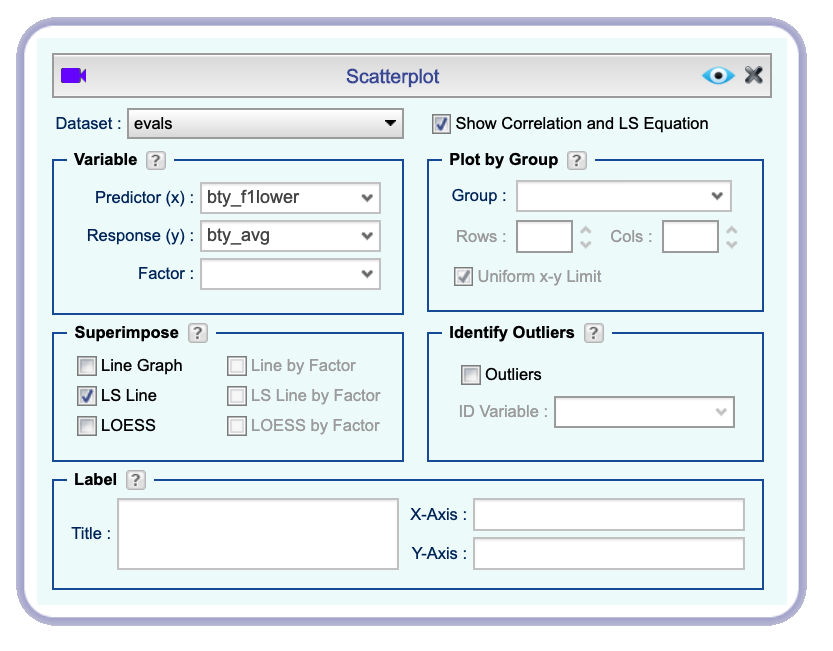

*Scatterplot of bty_avg vs. bty_f1lower*

As expected, the relationship is quite strong—after all, the average score is calculated using the individual scores. You can actually look at the relationships between all beauty variables (columns 13 through 19) using a matrix plot.

In the **Linear Regression** module, select the dataset *evals*. In the `Response` dropdown select *bty_avg*, and in the `Formula` box type in

```r
bty_f1lower  + bty_f1upper + bty_f2upper + bty_m1lower + bty_m1upper + bty_m2upper
```

In order not to make spelling errors in typing variable names, you can double-click the names of the variables on the column labeled `Variables`. When done, click the `Preview` button to see the matrix plot.

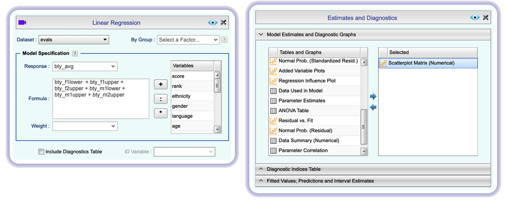

*Creating a scatterplot matrix to show the relationships between beauty variables*

These variables are collinear (correlated), and adding more than one of these variables to the model would not add much value to the model. In this application and with these highly-correlated predictors, it is reasonable to use the average beauty score as the single representative of these variables.

In order to see if beauty is still a significant predictor of professor score after you’ve accounted for the professor’s gender, you can add the gender term into the model. To do this, we have to start with the *m_bty* model, open the menu, click the `+` sign, and double-click *gender* to add it to the `Formula` box.

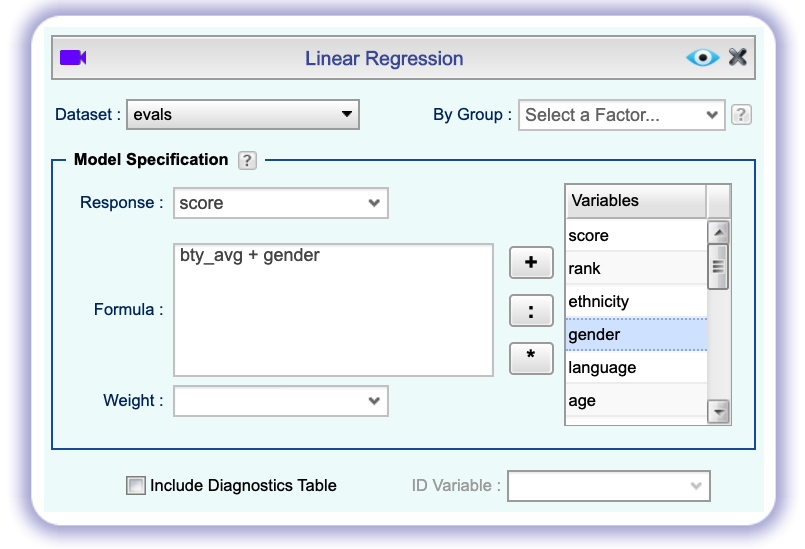

*Fitting a multiple regression model*

Note that the estimate for *gender* is now called *gendermale*. You’ll see this name change whenever you introduce a categorical variable. The reason is that Rguroo recodes *gender* from having the values of *male* and *female* to being an indicator variable called *gendermale* that takes a value of $0$ for female professors and a value of $1$ for male professors. (Such variables are often referred to as “dummy” variables.)

As a result, for female professors, the parameter estimate is multiplied by zero, leaving the intercept and slope form familiar from simple regression.

$$\begin{aligned}
\widehat{score} &= \hat{\beta}_0 + \hat{\beta}_1 \times bty\_avg + \hat{\beta}_2 \times (0) \\
&= \hat{\beta}_0 + \hat{\beta}_1 \times bty\_avg\end{aligned}$$

1. What is the equation of the line corresponding to male professors? (**Hint:** For male professors, the parameter estimate is multiplied by 1.) For two professors who received the same beauty rating, which gender tends to have the higher course evaluation score?

The decision to call the indicator variable *gendermale* instead of *genderfemale* has no deeper meaning. Rguroo simply codes the category that comes first alphabetically as a $0$. You can change the reference level of a categorical variable, which is the level that is coded as a 0, by opening the , selecting the variable of interest, and dragging-and-dropping the desired reference level to the top of the list, as shown below:

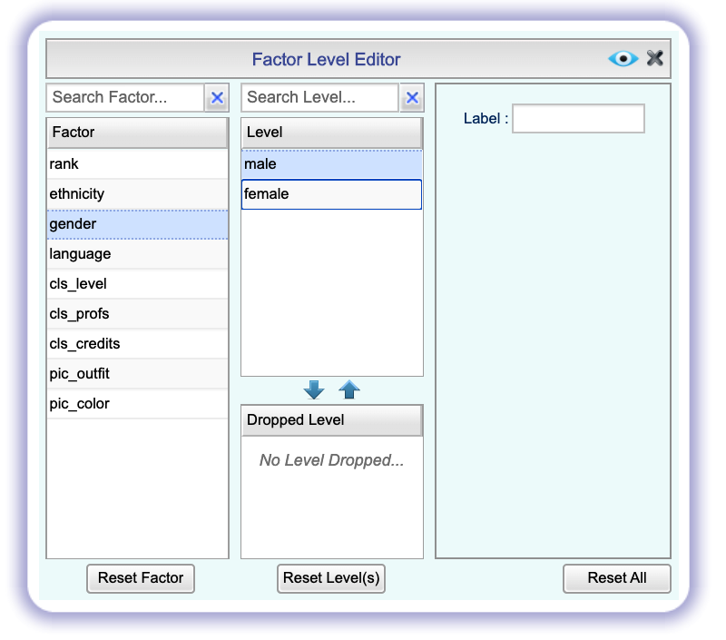

*Using the Factor Level Editor to change order of the levels*

**Save** the new model and report as *m_bty_gender*.

1. Create a new model with *gender* removed and *rank* added in. How does Rguroo appear to handle categorical variables that have more than two levels? Note that the *rank* variable has three levels: *teaching*, *tenure track*, *tenured*.

The interpretation of the coefficients in multiple regression is slightly different from that of simple regression. The estimate for *bty_avg* reflects how much higher a group of professors is expected to score if they have a beauty rating that is one point higher *while holding all other variables constant*. In this case, that translates into considering only professors of the same rank with *bty_avg* scores that are one point apart.

## The search for the best model

1. Which variable would you expect to have the highest p-value in this model? Why? **Hint:** Think about which variable would you expect to not have any association with the professor score.

Let’s create and run the model.

Keep *score* as the `Response` but now, set the `Formula` box to read:

```r
rank + gender + ethnicity + language + age +
  cls_perc_eval + cls_students + cls_profs + cls_credits +
  bty_avg + pic_outfit + pic_color
```

Remember that, to avoid typos, you can double-click the variable names in the `Variables` section.

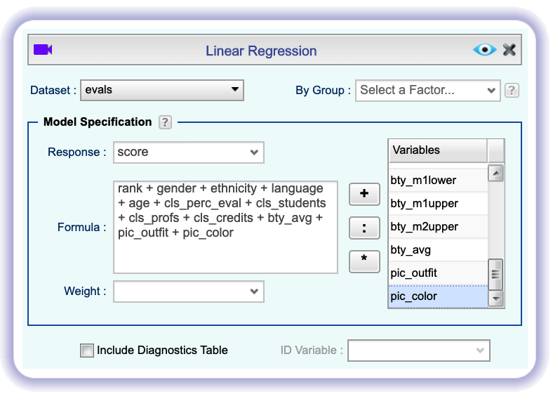

*Fitting the full model in the Linear Regression module*

**Save** this model and report as *m_full*.

1. Check your suspicions from the previous exercise. Include a screenshot of the model output in your response.
2. Interpret the coefficient associated with the ethnicity variable.
3. Open the menu. Delete the variable with the highest p-value from the `Formula` box and re-fit the model.Did the coefficients and significance of the other explanatory variables change? (One of the things that makes multiple regression interesting is that coefficient estimates depend on the other variables that are included in the model.) If not, what does this say about whether or not the dropped variable was collinear with the other explanatory variables?

One approach to obtain a final model is called *backward-selection*. In this approach, the model selection is stepwise. At each step, you remove the predictor variable with the highest p-value from the model, and refit. You continue this process until all the p-values are less than or equal to a threshold value, say 0.05.

1. Using backward-selection and p-value with a threshold of 0.05 as the selection criterion, determine the best model. You do not need to show all steps in your answer, just the output for the final model. Also, write out the linear model for predicting score based on the final model you settle on.

**Save** the final model and report as *m_final*.

1. Verify that the conditions for this model are reasonable using diagnostic plots.
2. The original paper describes how these data were gathered by taking a sample of professors from the University of Texas at Austin and including all courses that they have taught. Considering that each row represents a course, could this new information have an impact on any of the conditions of linear regression?
3. Based on your final model, describe the characteristics of a professor and course at University of Texas at Austin that would be associated with a high evaluation score.
4. Would you be comfortable generalizing your conclusions to apply to professors generally (at any university)? Why or why not?

This work is licensed under a [Creative Commons Attribution-ShareAlike 4.0 International License](http://creativecommons.org/licenses/by-sa/4.0/). Rguroo.com, the Rguroo.com logo, and all other trademarks, service marks, graphics and logos used in connection with Rguroo.com or the Website are trademarks or registered trademarks of Soflytics Corp. in the USA and other countries and are not included under the CC-BY-SA license.